# L12 Shiny 3

Data Visualization (STAT 302)

Author

INSTRUCTIONS

## Overview

Building complex apps can be a daunting task. Such apps typically involve advanced planning, data manipulation/restructuring, defining functions and sub-routines, computing/resource allocation decisions, and the process is almost never linear in nature. One should always try to think several steps ahead or even plan for future adjustments (i.e. efficient coding). Obviously, building complex shiny apps requires a deep understanding of how to construct plots/graphics in R. Fortunately, we spent the first part of the course developing a deep understanding of `ggplot2`.

The goal of this lab is to leverage this knowledge to reinforce and extend the `shiny` techniques we have learned.

## Dataset

For Exercise 1 you will need to unzip/decompress the provided `data.zip` file and then place the unzipped/decompressed `data` folder into the app directory. This folder contains the `.shp` file (shape files) with the state/county geometries and other variables needed for the app.

## Submission Guidelines

**Warning**

There are **2 assignments** to submit for this lab.

1. You will be submitting as zip file that contains all app directories — each app gets a directory/file). See the **shiny Labs (Description)** page on Canvas for complete instructions. The zip file should follow our standard naming convention (e.g. **Lasname_Fristname_L12.zip**).
2. You will also submit a url/link to the `L12 shiny 3: url/link` Canvas assignment.

## Exercises

### Exercise 1

Recreate the app pictured in Figure 1 below. It has two widgets, one for state and one for the variable.

*Hint*: [Lesson 5](https://shiny.rstudio.com/tutorial/written-tutorial/lesson5/) may have helpful parts on creating widgets, if you get stuck.

Figure 1: App Screenshots

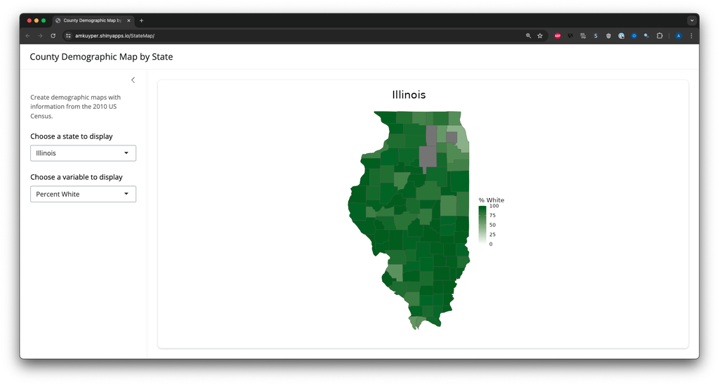

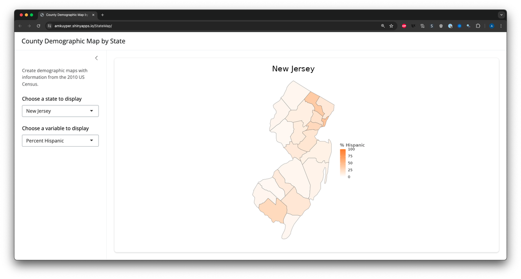

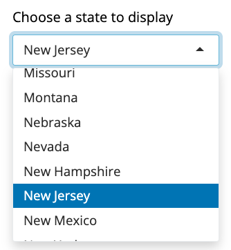

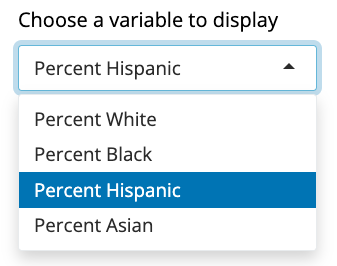

1. read in `data/county_data.shp` using the `sf::read_sf()`
2. create a widget to select the state - may be helpful to extract a vector of unique state names from the dataset
3. create a widget for variable with 4 options: `"Percent White"`, `"Percent Black"`, `"Percent Hispanic"`, `"Percent Asian"`
4. note the colors you will use are `"darkgreen"`, `"black"`,`"darkorange"`, and `"darkviolet"`, respectively.
5. in the server define:
   - a new dataset that is subset by state (pick any state for now, maybe `"Illinois"`, we will use the widget later)
   - a variable assigning the variable to display from your dataset (ie: `var <- "white"`)
   - a variable for the color. (ie: `color <- "darkgreen"`)

   *Helpful tip*: It is easier to define placeholder variables in the server that will change based on widget selection. But don’t link these to your widgets just yet! Let’s get a working plot first! This way we will be able to run the ggplot code and debug in your file rather than having to run the app every time to see our plot.
6. After you define these 3 objects, use ggplot to make your plot. The plot should use your new dataset, `var`, and `color` defined above.

   *Helpful tip*: This is useful because if done correctly when you link the widgets you will not have to make any adjustments to your working plot. All changes will occur in the variables defined before the plot.
7. Now link each widget one at a time to the variables you defined in the server, making sure everything runs correctly after each one to help with debugging.

### Exercise 2

Set up a **free shiny.io account** to share an app. [Lesson 7](https://shiny.rstudio.com/tutorial/written-tutorial/lesson7/) covers many methods to share your apps and your choice depends on the intended use of your app. Consider sharing shiny apps on your resume, cv, personal and/or professional website.

1. Begin by going to http://www.shinyapps.io/. click `sign up`. and follow the instructions to **set up a free account**.
2. Continue to follow the instructions to upload one of your apps (ANY app you want) to your new account.
3. After uploading your app ensure that it is working and then submit the url/link to the `L12 shiny 3: url/link` assignment on Canvas.

**Important**

Your submission for this lab is in 2 parts:

1. A zip folder with at least one app in it (Exercise 1), might have challenge apps in it, submitted to `L12 shiny 3` Canvas assignment.
2. A url/link submitted to the `L12 shiny 3: url/link` Canvas assignment.

The Canvas gradebook will be configured to handle these as one 20 point lab.

## Challenges

**Important**

Not required, but hope you try.

### Challenge 1

Work through [lesson 5](https://shiny.rstudio.com/tutorial/written-tutorial/lesson5/) which contains an exercise for practice. Call this app `census-app`. The lesson guides you through the construction of a moderately complex app and contains a few exercises during the process.

### Challenge 2

In the `app` you created in Exercise 1 add a selection after the states for a state bin plot of the contiguous 48 states. See Figure 2 below for clarification and/or for a closer look access the `shiny` app at https://amkuyper.shinyapps.io/state-demo-map-challenge/

Figure 2

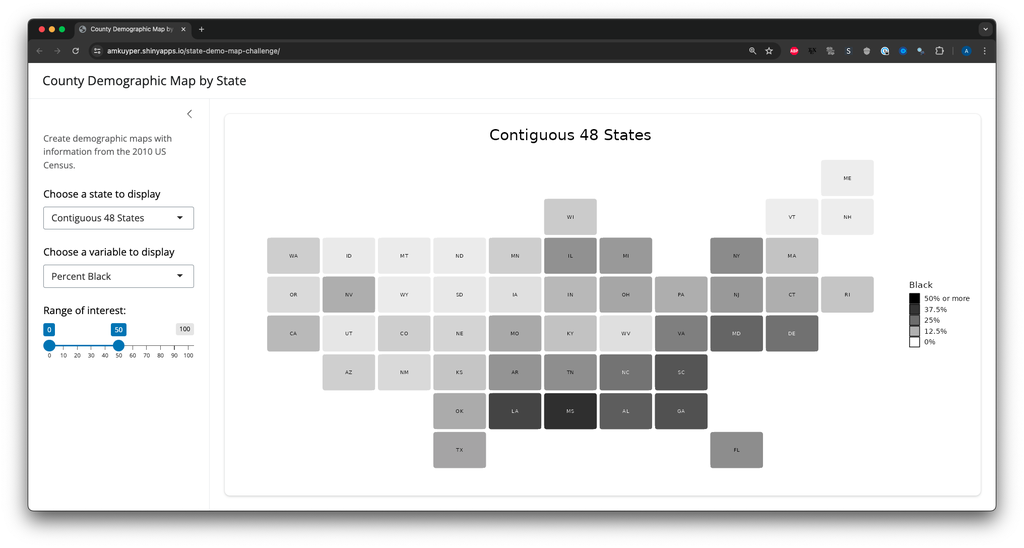

### Challenge 3

Work through [lesson 6](https://shiny.rstudio.com/tutorial/written-tutorial/lesson6/)

Create a copy of `stockVis` and rename it `stockVis-ggplot2`. Convert the graphic/plot code to `ggplot2` code. In addition make any alterations you might find interesting.

Images for an example are provided in Figure 3 below and can be explored by going to https://amkuyper.shinyapps.io/stockVis-ggplot2/.

Figure 3: `stockVizs` app screenshots

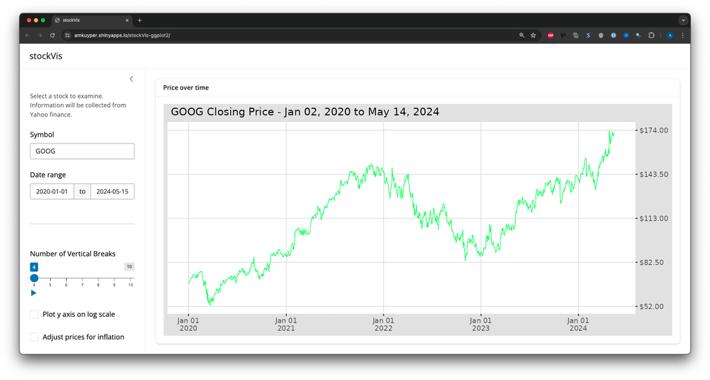

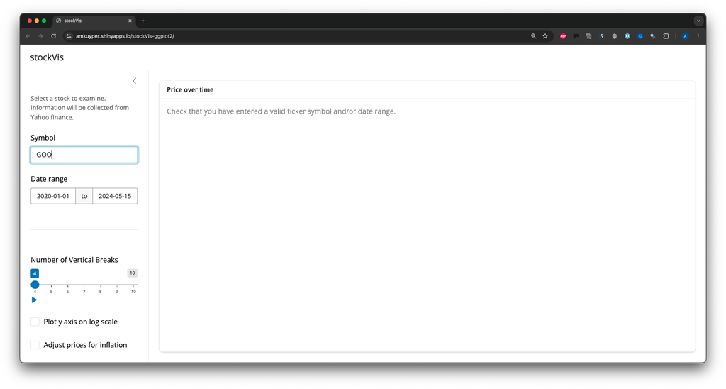

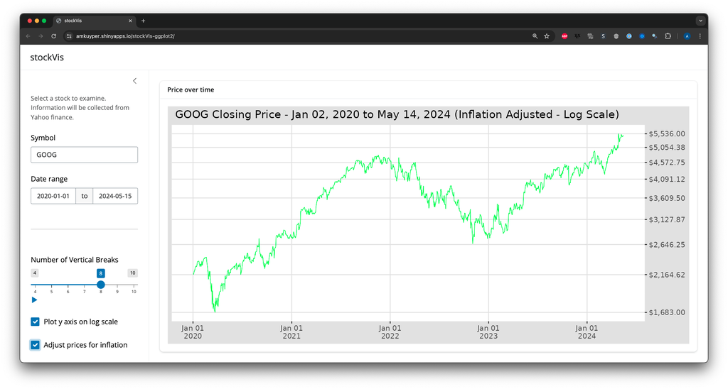